# class_5_28

lisa liubovich

2024-05-28

# Class Notes

Classification is when the response variable is cateegorical –> class or category (1, 2, … , j) that may or may not have order. For now, we are focusing on non-ordered categories (nominal categories)

1. Classification rate and classification error rate
   1. classification and classification errors (mis-classification)
      1. classification: predict y where $\hat{y}$ = ?
         1. classification rate: when the classification is correct $\rightarrow$ number of correct $\hat{y}$ / total number of observations; $\hat{y}$ = y OR 1 - mis-classification rate
         2. mis-classification rate: number of $\hat{y}$ $\neq$ y / total number of observations OR 1 - classification rate
   2. Binary response (ie., two-class) classification:
      1. Y = 0 or 1 OR failure or success OR negative or positive $\rightarrow$ depends on the context of the problem
         1. Confusion Matrix (aka Classification Matrix): TPR (Sensitivity), TNR (Specificity), FPR (1-Sensitivity), FPR (1- Specificity)
            1. two main kinds of mis-classification: False Positive or False Negative
            2. different texts may switch the arrangements of rows and columns
            3. Confusion matrix for binary response:

               | Observed “True | Predicted Negative ( $\hat{y}$ = 0) | Predicted Positive ( $\hat{y}$ = 1) |
               | --- | --- | --- |
               | negative (y = 0) | True Negative (count of observations with correct $\hat{y}$ = 0 ) aka TN | False Positive (FP) |
               | positive (y = 1) | False Negative (FN) | True Positive aka (TP) |

            4. Rates:
               1. True Positive Rate (TPR)/ sensitivity= TP/FN + TP
               2. False Negative Rate (FNR) / 1 - sensitivity = FN/FN + TP
               3. True Negative Rate (TNR) / specificity = TN/TN +FP
               4. False Positive Rate (FPR) / 1 - specificity = FP/TN + FP
            5. confusion matrix can be used for instances of multiple categories, but we no longer use the term true/false negative/positive
            6. depending on the tuning value, you will have different classification matrices in logistic regression $\rightarrow$ under each confusion matrix, there is sensitivity and specificity
         2. ROC curve and the area under the curve (more in logistic regression)
            1. receiver operating characteristic (ROC) curve is the combination of sensitivity and specificity
2. K-nearest neighbors (KNN) classifier $\rightarrow$ most intuitive classification method; also applies to regression analysis
   1. Distance and neighbors
      1. Example: K nearest neighbor(s) = smallest distance

         | observations | 1 | 2 | n |
         | --- | --- | --- | --- |
         | X1 | 8 | 7 | … |
         | X2 | 12 | 10 | … |
         | Y | 0 | 0 |  |
         | neighbor (defined by Euclidean distance); distance to (x1, x2) = (6,11) | $\sqrt(6-8)^2 + (11-12)^2$ = $\sqrt5$ | $\sqrt(6-7)^2 + (11-10)^2$ = $\sqrt5$ |  |

      2. ties can be broken by flipping a coin or other random methods
      3. once we find the k nearest neighbor, classify $\hat{y}$ using the y’s of the K-nearest neighbors by popular vote
   2. Flexibility of KNN: tuning K using prediction error rate (or correct classification rate)
      1. choosing the k $\rightarrow$ k is tuning parameter
      2. k = 1 is used often $\rightarrow$ in practice people use odd numbers for k to avoid ties
      3. largest possible k is sample size n
      4. flexibility $\rightarrow$ k = 1 is when model is most flexible and k = n is when model is least flexible
      5. if we are looking at training accuracy, the most flexible model will give us the highest accuracy and the least flexible model gives us the least accuracy $\rightarrow$ what we really care about is testing accuracy
      6. if the model is most flexible, the accuracy will be low and if the model is least flexible (overfit), the accuracy will be also be low (underfit) $\rightarrow$ the ideal level of k will fall somewhere in the model and provide the highest accuracy
3. Logistic regression $\rightarrow$ called a regression because depending on what measurement is called the repose, it can indeed have a numerical variable
   1. Logistic regression model (inflexible, parametric)
      1. Y = 0, 1 (binary) but it can be generalized into multiple categories
         1. 0 can be referred to as negative or failure
         2. 1 can be referred to as positive or success
      2. Pr(success) = P(Y =1) = $\pi$ $\rightarrow$ Pr(failure) = P(Y = 0) = 1 - $\pi$
      3. log(odds) = log( $\pi$ / 1 - $\pi$ ) = $\beta_0$ + $\beta_1$ $X_{1}$ + $\beta_2$ $X_{2}$
   2. Estimate the regression coefficients
      1. Maximum Likelihood Estimation Method: find the estimates $\hat\beta_{i}$ such that the likelihood function is L( $\hat\beta_0$ , $\hat\beta_1$ , $\hat\beta_2$ ) = ( $\hat\pi_1$ )^$y_1$ (1 - $\hat\pi_1$)^ 1- $y_1$ ( $\hat\pi_2$)^$y_2$ ( 1 - $\hat\pi_2$)^ $y_2$ … ( $\hat\pi_n$ )^$y_n$ (1 - $\hat\pi_n$)^1- $y_n$ where $\hat\pi_i$ = e^( $\beta_0$ + $\beta_1$ $X_{i1}$ + $\beta_2$ $X_{i2}$) / 1 + e^($\beta_0$ + $\beta_1$ $X_{i1}$ + $\beta_2$ $X_{i2}$ ) $\rightarrow$ goal is to maximize this
      2. derivative $\rightarrow$ newton-ramson $\rightarrow$ scoring method
      3. important output: maximum iterations reached means the machine gave up
         1. if the output is 5 or 10, that means that it can effectively find an estimation using a set number of iterations
   3. predict the probability
      1. $\hat\pi$ = e^( $\beta_0$ + $\beta_1$ $X_{1}$ + $\beta_2$ $X_{2}$) / 1 + e^($\beta_0$ + $\beta_1$ $X_{1}$ + $\beta_2$ $X_{2}$ )
   4. predict the class i.e. classification
      1. $\hat{Y}$ = 0, 1 $\rightarrow$ pick which value has higher probability
      2. and that is equivalent to setting a threshold of $\hat\pi$ $\le$ 0.5 or $\hat\pi$ $\ge$ 0.5
   5. Tune the cutoff value using ROC (and Loss function)
      1. can tune c to maximize the classification rate/minimize mis-classification rate
      2. this is where ROC comes to play
         1. consider a bunch of choices for the cutoff value c: use the cutoff value to determine specificity and sensitivity

            | c | specificity | sensitivity |
            | --- | --- | --- |
            | 0 |  |  |
            | 0.01 |  |  |
            | 0.02 |  |  |
            | … |  |  |
            | 0.99 |  |  |
            | 1.0 |  |  |

      3. instead of a table, we represent this with a plot where sensitivity (TPR) is the vertical axis and the 1 - specificity (FPR) is on the horizontal axis $\rightarrow$ see classification document for visualization
      4. ROC is guaranteed to be bounded between 0 and 1 and is smooth in theory but wobbly in practice
      5. ROC helps with:
         1. picking the optimal c value
         2. the area under the curve (AUC): we want models with large AUC $\rightarrow$ very important to distinguish between training and testing here
            1. for the training AUC, it is not guaranteed but expected to keep increasing as model complexity increases
            2. testing AUC is what really matters

# **1 KNN and introduction to classfication rate, confusion matrix, etc.**

- KNN is a nonparametric, discriminative, supervised learning algorithm for classification.

## **1.1 Prepare the data set: Fuel Economy (`Auto` in `ISLR2` Package)**

Consider the `Auto` data set in the `ISLR2` package. This data frame has 392 observations on the following 9 variables.

- `mpg`: miles per gallon
- `cylinders`: Number of cylinders between 4 and 8
- `displacement`: Engine displacement (cu. inches)
- `horsepower`: Engine horsepower
- `weight`: Vehicle weight (lbs.)
- `acceleration`: Time to accelerate from 0 to 60 mph (sec.)
- `year`: Model year (modulo 100)
- `origin`: Origin of car (1. American, 2. European, 3. Japanese)
- `name`: Vehicle name

We will create a new categorical variable `econ` (fuel economy) based on `mpg` by the quarantines.

```r
library(ISLR2)

auto.data <- ISLR2::Auto
summary(auto.data$mpg)
```

```
##    Min. 1st Qu.  Median    Mean 3rd Qu.    Max.
##    9.00   17.00   22.75   23.45   29.00   46.60
```

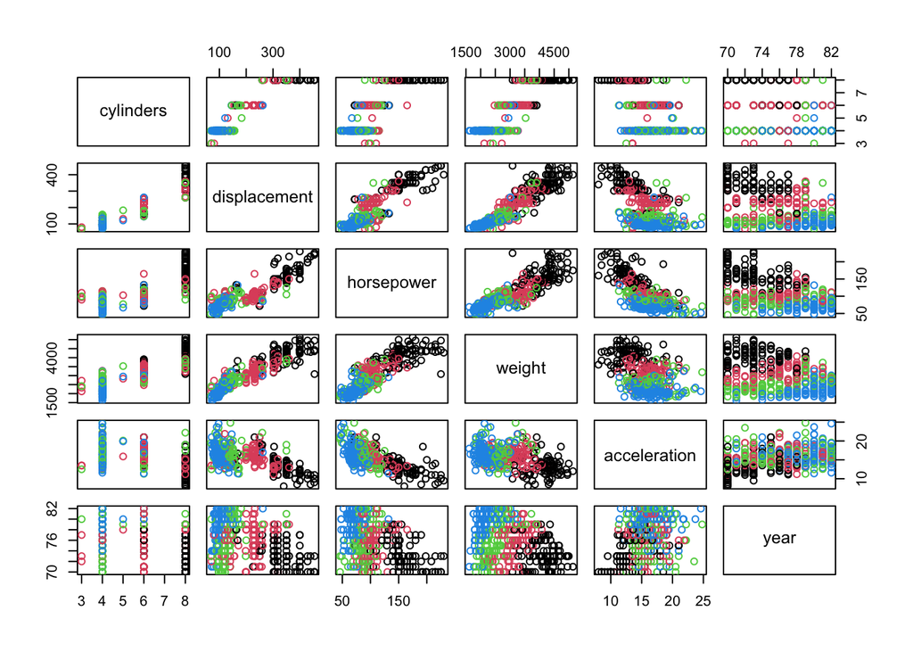

```r
auto.data$econ <- cut(auto.data$mpg, breaks=quantile(auto.data$mpg), include.lowest=TRUE,
                      labels=c("Poor", "OK", "Good", "Excellent"))
pairs(auto.data[, 2:7], col=auto.data$econ)
```

We will also split the data set at 60%-40% for training and validation (or testing).

```r
set.seed(12345)  # Only for example purpose.
training_pct <- 0.6
Z <- sample(nrow(auto.data), floor(training_pct*nrow(auto.data)))
auto.training <- auto.data[Z, ]
auto.testing <- auto.data[-Z, ]
c(nrow(auto.data), nrow(auto.training), nrow(auto.testing))
```

```
## [1] 392 235 157
```

## **1.2 R function `knn()`**

```r
# install.packages("class")
library(class)
```

This function requires at least 4 input arguments:

- train: Xs (i.e., predictors) in the training set.
- test: Xs (i.e., predictors) in the testing set.
- cl: Observed classification (i.e., response) in the training set.
- k: number of neighbors.

The output of the function is the predicted classification of the testing set.

## **1.3 Fit KNN model to the fuel economy data.**

Recall that column 2 - 7 are the predictors.

```r
colnames(auto.training)[2:7]
```

```
## [1] "cylinders"    "displacement" "horsepower"   "weight"       "acceleration"
## [6] "year"
```

```r
X.train <- auto.training[, 2:7]
Y.train <- auto.training$econ

X.test <- auto.testing[, 2:7]
Y.test <- auto.testing$econ

econ.knn <- knn(train=X.train, test=X.test, cl=Y.train, k = 3)

table(Y.test, econ.knn)  # Confusion matrix on the testing data set.
```

```
##            econ.knn
## Y.test      Poor OK Good Excellent
##   Poor        31  3    0         0
##   OK           6 23    5         0
##   Good         1  8   30         5
##   Excellent    0  2   19        24
```

```r
mean(Y.test == econ.knn) # correct classification rate on the testing data.
```

```
## [1] 0.6878981
```

## **1.4 Tuning K to maximize correct classification rate.**

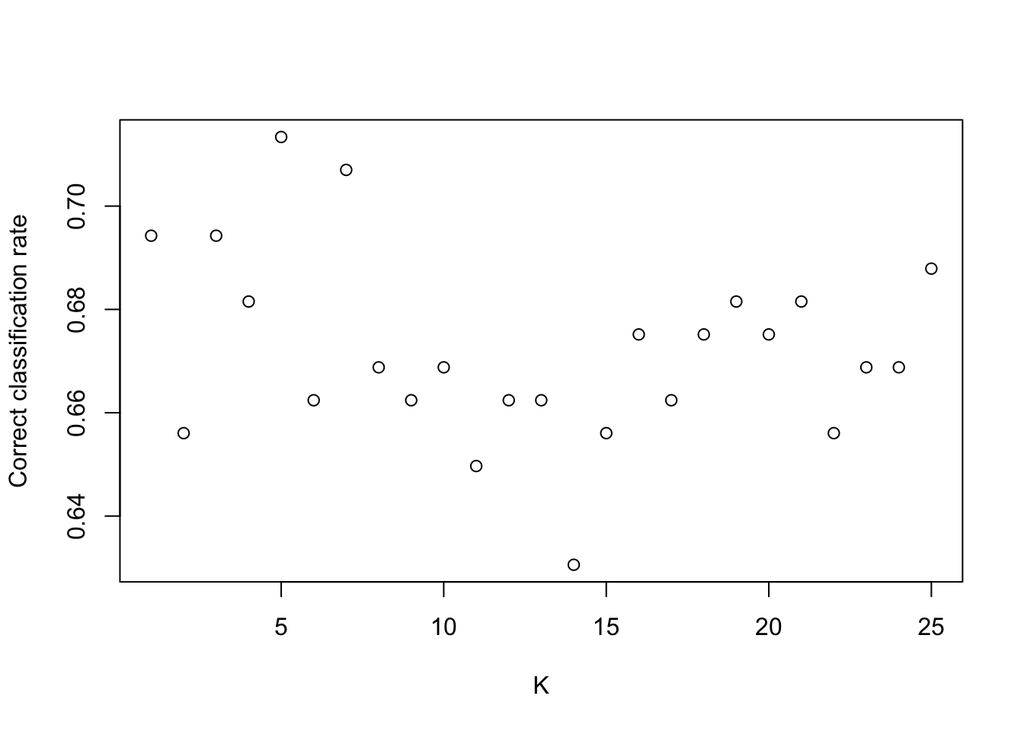

```r
Kmax <- 25  # Set the largest K I would consider for this study.
class.rate <- rep(0, Kmax)
for (i in 1:Kmax) {
  knn.out <- knn(train=X.train, test=X.test, cl=Y.train, k = i)
  class.rate[i] <- mean(Y.test == knn.out)
}

plot(c(1:Kmax), class.rate, xlab="K", ylab="Correct classification rate")
```

```r
k.opt <- which.max(class.rate)
c(k.opt, class.rate[which.max(class.rate)])  # Optimal K.
```

```
## [1] 5.0000000 0.7133758
```

```r
econ.knnOpt <- knn(train=X.train, test=X.test, cl=Y.train, k = k.opt)
table(Y.test, econ.knnOpt)  # Confusion matrix on the testing data set.
```

```
##            econ.knnOpt
## Y.test      Poor OK Good Excellent
##   Poor        30  4    0         0
##   OK           5 25    4         0
##   Good         1 11   31         1
##   Excellent    0  4   17        24
```

```r
mean(Y.test == econ.knnOpt) # correct classification rate on the testing data.
```

```
## [1] 0.7006369
```

**Remark**

- Note that, in this example, the classification rate is above 0.6 for K=1,2,…,25𝐾=1,2,…,25, and the change is relatively small. If you change the random seed, or change the training percentage, you may get a very different K.
- Instead of splitting the data set once, a better approach is conduct *cross-validation*. We’ll discuss it next week.

# **2 Logistic regression**

- Logistic regression is a parametric, discriminative, supervised learning algorithm for classification and inference.

## **2.1 The Depression data (read data from a file)**

A study a 3,189 high school students has been concluded in order to find socioeconomic and family factors that my be associated with stress and depression. Data Set **depression.csv** contains some variables obtained from this study.

- `ID`: Participant’s identification number
- `Gender`: Female or Male
- `Guardian_status`: 0 = does not live with both natural parents. 1 = with both parents.
- `Cohesion_score`: 16-80, large value indicates strong connection to the community.
- `Depression_score`: 0 - 60
- `Diagnosis`: Clinic diagnosis of major depression. 0 = negative (no), 1 = positive (yes)

```r
depr <- read.csv("./depression_data.csv", header=T)
summary(depr)
```

```
##        ID          Gender          Guardian_status  Cohesion_score
##  Min.   :   1   Length:3189        Min.   :0.0000   Min.   :16.00
##  1st Qu.: 800   Class :character   1st Qu.:0.0000   1st Qu.:48.00
##  Median :1597   Mode  :character   Median :1.0000   Median :58.00
##  Mean   :1597                      Mean   :0.5177   Mean   :56.24
##  3rd Qu.:2394                      3rd Qu.:1.0000   3rd Qu.:66.00
##  Max.   :3191                      Max.   :1.0000   Max.   :80.00
##
##  Depression_score   Diagnosis
##  Min.   : 0.00    Min.   :0.0000
##  1st Qu.: 8.00    1st Qu.:0.0000
##  Median :14.00    Median :0.0000
##  Mean   :15.56    Mean   :0.1572
##  3rd Qu.:21.00    3rd Qu.:0.0000
##  Max.   :54.00    Max.   :1.0000
##                   NA's   :2731
```

```r
# Remove missing values in Diagnosis
depr <- na.omit(depr)

# Since we'll use logistic regression for this data set. Convert the response as 0-1 or a factor.
depr$Diagnosis <- 1*(depr$Diagnosis == 1)
head(depr)
```

```
##    ID Gender Guardian_status Cohesion_score Depression_score Diagnosis
## 10 10 Female               0           69.0               30         0
## 13 13   Male               0           72.0                3         0
## 28 28   Male               1           78.0                9         0
## 30 30   Male               0           56.5               12         0
## 38 40 Female               0           28.0               46         0
## 43 45   Male               0           62.0               15         1
```

```r
# Split data (optional in real life)
set.seed(23456)  # Only for example purpose.
training_pct <- 0.6
Z <- sample(nrow(depr), floor(training_pct*nrow(depr)))
depr.training <- depr[Z, ]
depr.testing <- depr[-Z, ]
```

For now, we’ll only consider logistic regression for binary (0-1, yes-no, success-failure, etc) response.

```r
head(depr)
```

```
##    ID Gender Guardian_status Cohesion_score Depression_score Diagnosis
## 10 10 Female               0           69.0               30         0
## 13 13   Male               0           72.0                3         0
## 28 28   Male               1           78.0                9         0
## 30 30   Male               0           56.5               12         0
## 38 40 Female               0           28.0               46         0
## 43 45   Male               0           62.0               15         1
```

## **2.2 `glm()` function and its output**

```r
depr.glm <- glm(Diagnosis ~ Gender + Guardian_status + Cohesion_score, family = binomial, data=depr.training)
summary(depr.glm)
```

```
##
## Call:
## glm(formula = Diagnosis ~ Gender + Guardian_status + Cohesion_score,
##     family = binomial, data = depr.training)
##
## Coefficients:
##                 Estimate Std. Error z value Pr(>|z|)
## (Intercept)      0.78591    0.67763   1.160  0.24613
## GenderMale      -0.79113    0.36369  -2.175  0.02961 *
## Guardian_status -0.96344    0.37050  -2.600  0.00931 **
## Cohesion_score  -0.03484    0.01358  -2.565  0.01032 *
## ---
## Signif. codes:  0 '***' 0.001 '**' 0.01 '*' 0.05 '.' 0.1 ' ' 1
##
## (Dispersion parameter for binomial family taken to be 1)
##
##     Null deviance: 247.98  on 273  degrees of freedom
## Residual deviance: 225.87  on 270  degrees of freedom
## AIC: 233.87
##
## Number of Fisher Scoring iterations: 5
```

```r
depr.glm$fitted.value[1:5]
```

```
##       2852        279        797       3030       1115
## 0.13165959 0.22538084 0.27076827 0.08531709 0.33688550
```

## **2.3 Predict the probability and the log(odds)**

Predict the probability using `predict()` function with argument `type="response"`.

```r
p1 <- predict(depr.glm, newdata=data.frame(Gender="Female", Guardian_status=0, Cohesion_score=50),
        type = "response")
p1
```

```
##         1
## 0.2777014
```

```r
odds1 <- p1/(1-p1)  # probability -> odds.

p2 <- predict(depr.glm, newdata=data.frame(Gender="Female", Guardian_status=1, Cohesion_score=50),
        type = "response")
odds2 <- p2/(1-p2)

cbind(p1, odds1, p2, odds2)
```

```
##          p1    odds1        p2     odds2
## 1 0.2777014 0.384469 0.1279357 0.1467045
```

Predicting log-odds (i.e., the linear function) is not used often. The example is to show how to compute the probability from log-odds.

```r
logOdds1 <- predict(depr.glm, newdata=data.frame(Gender="Female", Guardian_status=0, Cohesion_score=50),
        type = "link")
exp(logOdds1)/(1+exp(logOdds1))  # log-odds -> probability
```

```
##         1
## 0.2777014
```

## **2.4 Predict the class. Confusion matrix, classfication rate, TPR, TNR, and error rate.**

```r
cutoff <- 0.4  # Try cutoff <-0.5 and see what happens.
predicted.class <- 1*(depr.glm$fitted.values > cutoff)

# Confusion matrix
table(depr.training$Diagnosis, predicted.class)
```

```
##    predicted.class
##       0   1
##   0 219   9
##   1  44   2
```

```r
# Correct classification rate
mean(depr.training$Diagnosis == predicted.class)
```

```
## [1] 0.8065693
```

```r
# Error rate
1 - mean(depr.training$Diagnosis == predicted.class)
```

```
## [1] 0.1934307
```

```r
# TPR, FNR, TNR and FPR
prop.table(table(depr.training$Diagnosis, predicted.class), 1)
```

```
##    predicted.class
##              0          1
##   0 0.96052632 0.03947368
##   1 0.95652174 0.04347826
```

Note that:

- Although the training error rate is 19% (i.e., classification rate 81%), the False Negative rate, P(Yˆ=0|Y=1)𝑃(𝑌^=0|𝑌=1), is very high (95.6%).
- If we increase the cutoff value, we’ll have even higher FNR. (Why?)
- Checking the prediction error within the training set can be misleading. We will use the testing data set soon.

## **2.5 ROC curve and cutoff tuning**

Here is a function that can draw ROC.

- The function optimal cut-off that maximizes sensitivity+specificity𝑠𝑒𝑛𝑠𝑖𝑡𝑖𝑣𝑖𝑡𝑦+𝑠𝑝𝑒𝑐𝑖𝑓𝑖𝑐𝑖𝑡𝑦. I.e, it maximized TPR+TNR𝑇𝑃𝑅+𝑇𝑁𝑅, or TPR+(1−FPR)𝑇𝑃𝑅+(1−𝐹𝑃𝑅),
- **Be sure to convert the response variable to 0-1 and call it `y` in the data frame.**

```r
roc.analysis <-function (object, newdata = NULL, newplot=TRUE)
{
  if (is.null(newdata)) {
    pi.tp <- object$fitted[object$y == 1]
    pi.tn <- object$fitted[object$y == 0]
  }
  else {
    pi.tp <- predict(object, newdata, type = "response")[newdata$y == 1]
    pi.tn <- predict(object, newdata, type = "response")[newdata$y == 0]
  }

  pi.all <- sort(c(pi.tp, pi.tn))
  sens <- rep(1, length(pi.all)+1)
  specc <- rep(1, length(pi.all)+1)
  for (i in 1:length(pi.all)) {
    sens[i+1] <- mean(pi.tp >= pi.all[i], na.rm = T)
    specc[i+1] <- mean(pi.tn >= pi.all[i], na.rm = T)
  }

  npoints <- length(sens)
  area <- sum(0.5 * (sens[-1] + sens[-npoints]) * (specc[-npoints] -
        specc[-1]))

  lift <- (sens - specc)[-1]
  cutoff <- pi.all[lift == max(lift)][1]
  sensopt <- sens[-1][lift == max(lift)][1]
  specopt <- 1 - specc[-1][lift == max(lift)][1]

  par(pty="s")
  if (newplot){
  plot(specc, sens, xlim = c(0, 1), ylim = c(0, 1), type = "s",
            xlab = "FPR = 1-specificity", ylab = "TPR = sensitivity", main="ROC")
  abline(0, 1)
  }
  else lines(specc, sens, type="s", lty=2, col=2)

  list(pihat=as.vector(pi.all), sens=as.vector(sens[-1]),
  spec=as.vector(1-specc[-1]), area = area, cutoff = cutoff,
  sensopt = sensopt, specopt = specopt)
}
```

Draw ROC curves for both training and testing data sets.

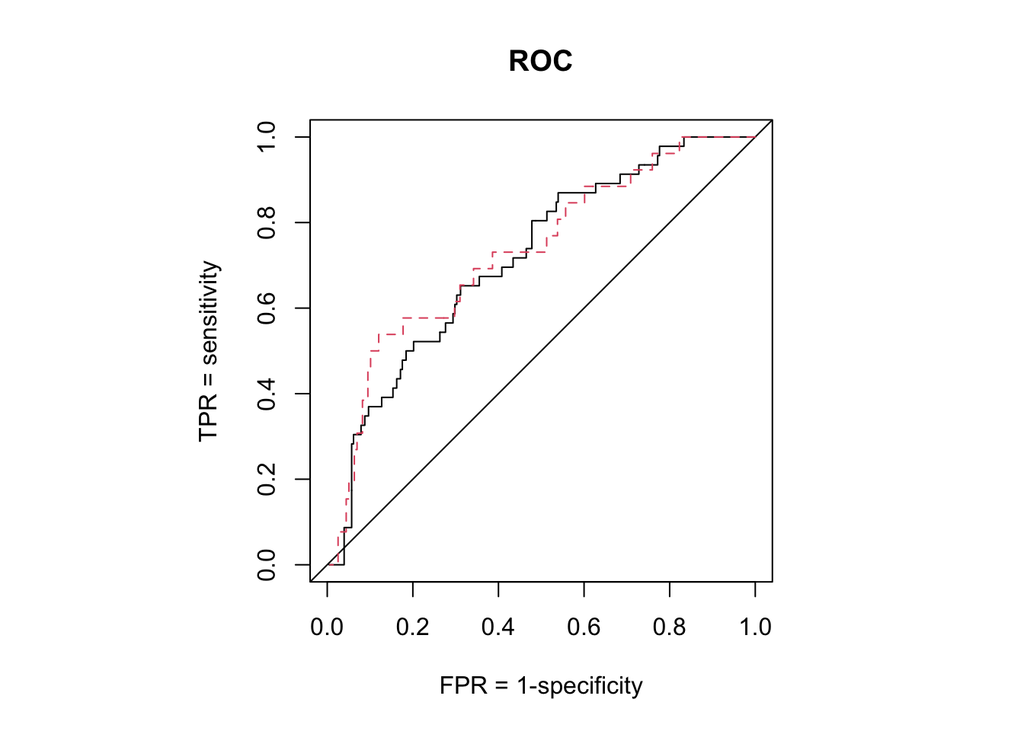

```r
train.ROC <- roc.analysis(depr.glm)

depr.testing$y <- 1*(depr.testing$Diagnosis == 1)
test.ROC <- roc.analysis(depr.glm, newdata=depr.testing, newplot=F)
```

Find the optimal *cutoff from the training* data set. Then apply it to the *testing data to compute the prediction error rate*.

```r
train.ROC[(4:7)]
```

```
## $area
## [1] 0.71496
##
## $cutoff
##      1307
## 0.1871962
##
## $sensopt
## [1] 0.6521739
##
## $specopt
## [1] 0.6798246
```

```r
cutoff <- train.ROC$cutoff
pred.prob <- predict(depr.glm, newdata=depr.testing, type="response")
predicted.class <- 1*(pred.prob > cutoff)

# Confusion matrix
table(depr.testing$Diagnosis, predicted.class)
```

```
##    predicted.class
##       0   1
##   0 109  49
##   1  10  16
```

```r
# Correct classification rate
mean(depr.testing$Diagnosis == predicted.class)
```

```
## [1] 0.6793478
```

```r
# Error rate
1 - mean(depr.testing$Diagnosis == predicted.class)
```

```
## [1] 0.3206522
```

## **2.6 Extra: logistic regression for Binomial counts data**

Sometimes, data may be aggregated according to unique X-combination. I.e., Each row is a summary of ni𝑛𝑖 observations that have the same X-values. The response variable(s) are the **counts** of successes (1) and failures (0). The logistic regression model can still be applied. However, note that:

- The R syntax need to be modified. One way is to use `glm(c(count.of.success, count.of.failures) ~ x1 + x2 ......)`
- We can still study the association, and predict the probabilities.
- We will NOT predict individual’s classification.

Here is an example using `menarche` data in `MASS` package.

```r
library(MASS)
data(menarche)

summary(menarche)
```

```
##       Age            Total           Menarche
##  Min.   : 9.21   Min.   :  88.0   Min.   :   0.00
##  1st Qu.:11.58   1st Qu.:  98.0   1st Qu.:  10.00
##  Median :13.08   Median : 105.0   Median :  51.00
##  Mean   :13.10   Mean   : 156.7   Mean   :  92.32
##  3rd Qu.:14.58   3rd Qu.: 117.0   3rd Qu.:  92.00
##  Max.   :17.58   Max.   :1049.0   Max.   :1049.00
```

```r
## fit the logistic regression model
logit.fit <- glm(cbind(Menarche,Total-Menarche)~Age, family=binomial(link=logit),data=menarche)
summary(logit.fit)
```

```
##
## Call:
## glm(formula = cbind(Menarche, Total - Menarche) ~ Age, family = binomial(link = logit),
##     data = menarche)
##
## Coefficients:
##              Estimate Std. Error z value Pr(>|z|)
## (Intercept) -21.22639    0.77068  -27.54   <2e-16 ***
## Age           1.63197    0.05895   27.68   <2e-16 ***
## ---
## Signif. codes:  0 '***' 0.001 '**' 0.01 '*' 0.05 '.' 0.1 ' ' 1
##
## (Dispersion parameter for binomial family taken to be 1)
##
##     Null deviance: 3693.884  on 24  degrees of freedom
## Residual deviance:   26.703  on 23  degrees of freedom
## AIC: 114.76
##
## Number of Fisher Scoring iterations: 4
```